# Violencia contra la mujer dentro del ámbito familiar

[figure not shown]

[figure not shown]

[figure not shown]

[figure not shown]

[figure not shown]

[figure not shown]

[figure not shown]

[figure not shown]

[figure not shown]

# Exploración de datos

### Tema de investigación

Esta investigación busca reconocer distintos rasgos a nivel individual que pueden determinar el surgimiento de casos de violencia contra la mujer dentro del ámbito familiar. La exposición a una situación de violencia puede verse impulsada por diversos aspectos dentro de la identidad personal como la etnia, sexo, religión u otros, lo que explicarían a su vez el grado de vulnerabilidad para convertirse en víctimas.

### Estructura del dataframe

```
tibble [21,321 x 14] (S3: tbl_df/tbl/data.frame)
 $ CASEID: chr [1:21321] "000102201  2" "000105201  2" "000105301  1" "000108301  2" ...
 $ D104  : num [1:21321] 0 0 1 0 1 0 0 0 0 0 ...
 $ D108  : num [1:21321] 0 0 0 0 0 0 0 0 0 0 ...
 $ D111  : num [1:21321] 0 0 0 0 1 0 0 0 0 0 ...
 $ V012  : num [1:21321] 22 44 34 38 33 26 35 31 27 24 ...
 $ V024  : chr [1:21321] "AMAZONAS" "AMAZONAS" "AMAZONAS" "AMAZONAS" ...
 $ V025  : num [1:21321] 1 1 1 1 1 1 1 1 1 1 ...
 $ V131  : num [1:21321] 10 10 10 10 10 10 10 10 10 10 ...
 $ V149  : num [1:21321] 5 5 3 5 5 5 5 5 4 5 ...
 $ V136  : num [1:21321] 3 5 4 5 5 3 4 4 6 4 ...
 $ V190  : num [1:21321] 5 4 3 3 5 2 5 3 2 5 ...
 $ V155  : Factor w/ 5 levels "no_leer","leer_palabras",..: 3 3 3 3 3 3 3 3 3 3 ...
 $ S119  : num [1:21321] 10 10 10 10 10 10 10 10 10 10 ...
 $ lengua: Factor w/ 2 levels "no_español","español": 2 2 2 2 2 2 2 2 2 2 ...
```

### Head dataframe

```
# A tibble: 40 x 14
   CASEID       D104  D108  D111  V012 V024   V025  V131  V149  V136  V190 V155
   <chr>       <dbl> <dbl> <dbl> <dbl> <chr> <dbl> <dbl> <dbl> <dbl> <dbl> <fct>
 1 000102201 ~     0     0     0    22 AMAZ~     1    10     5     3     5 leer~
 2 000105201 ~     0     0     0    44 AMAZ~     1    10     5     5     4 leer~
 3 000105301 ~     1     0     0    34 AMAZ~     1    10     3     4     3 leer~
 4 000108301 ~     0     0     0    38 AMAZ~     1    10     5     5     3 leer~
 5 000108501 ~     1     0     1    33 AMAZ~     1    10     5     5     5 leer~
 6 000110301 ~     0     0     0    26 AMAZ~     1    10     5     3     2 leer~
 7 000110701 ~     0     0     0    35 AMAZ~     1    10     5     4     5 leer~
 8 000301201 ~     0     0     0    31 AMAZ~     1    10     5     4     3 leer~
 9 000302201 ~     0     0     0    27 AMAZ~     1    10     4     6     2 leer~
10 000306001 ~     0     0     0    24 AMAZ~     1    10     5     4     5 leer~
# i 30 more rows
# i 2 more variables: S119 <dbl>, lengua <fct>
```

### Configuración de la variable dependiente

```r
data$violencia <- ifelse(data$D104 == 0 & data$D108 == 0 & data$D111 == 0, 1, 2)

# Sumar las variables de violencia emocional, sexual y cualquier resultado adverso de violencia
data$violencia_general <- data$D104 + data$D108 + data$D111

# Establecer un umbral para determinar la presencia de violencia general (por ejemplo, si la suma es mayor que 0)
data$violencia_general <- ifelse(data$violencia_general > 0, 1, 0)

data$violencia<-factor(data$violencia,
                                levels=1:2,
                                labels=c("No","Sí"))
```

# Descripción y configuración de variables

### Violencia

```
   No    Sí
15168  6153
```

### Nivel Educativo

```
sin_educacion      prim_inc      prim_com       sec_inc       sec_com
          321          2003          2202          3342          6758
          sup
         6695
```

### Nivel socioeconómico

Registra el nivel de riqueza de la persona entrevistada. Existen 5 niveles: Pobreza extrema, pobreza, riqueza moderada, rico, extremadamente rico.

```
pobre_ext     pobre     medio      rico  rico_ext
     6556      5818      4153      2886      1908
```

### Ámbito

Registra el ambito de residencia de la persona entrevista. Existen dos niveles: Urbano y rural.

```
urbano  rural
 14198   7123
```

### Presencia de violencia contra la mujer en el ámbito familiar

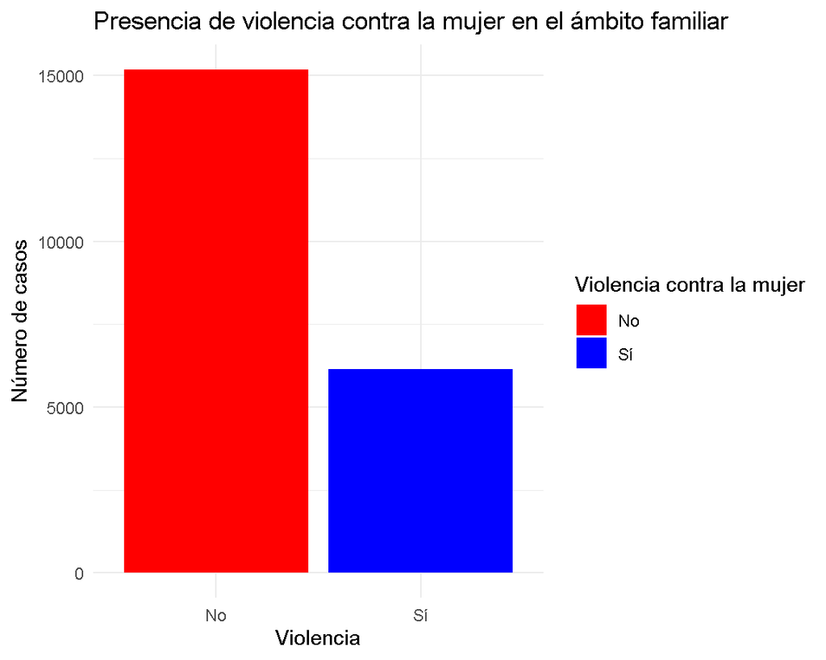

### Proporción de casos donde hubo y no hubo violencia en base al ámbito

```
     urbano rural
  No  10079  5089
  Sí   4119  2034
```

```
         urbano     rural
  No  0.7098887 0.7144462
  Sí  0.2901113 0.2855538
  Sum 1.0000000 1.0000000
```

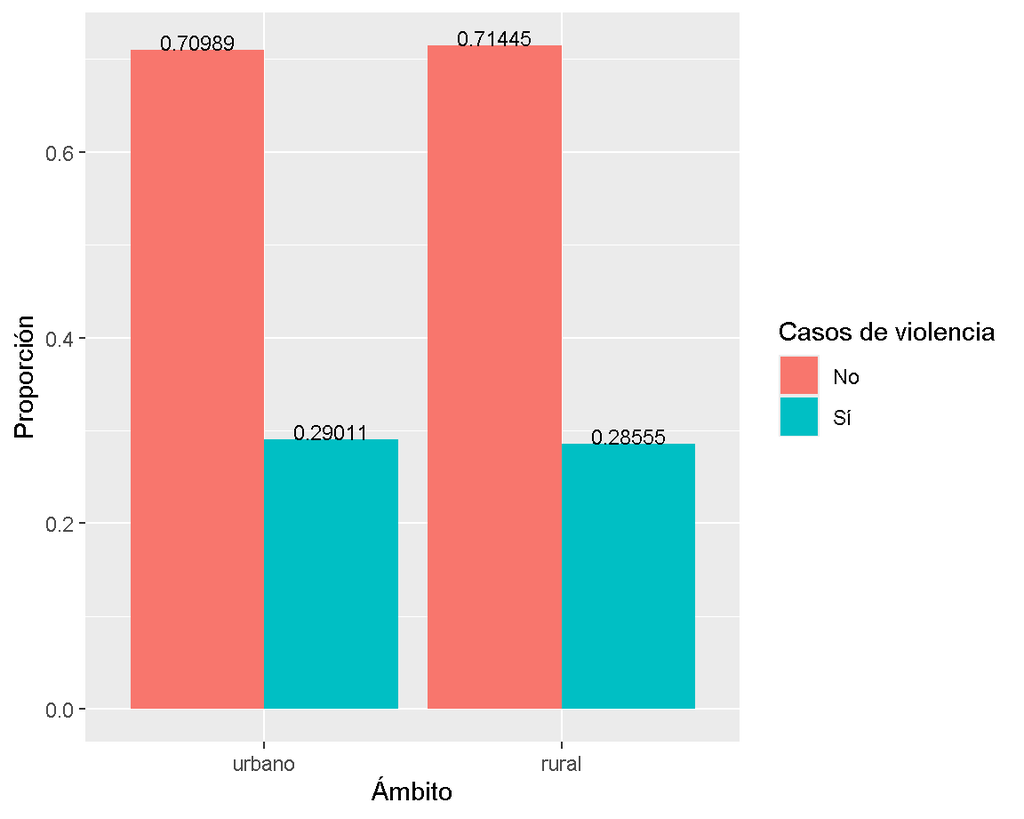

### Distribución de casos que registran al menos un tipo de violencia contra la mujer dentro del ámbito familiar

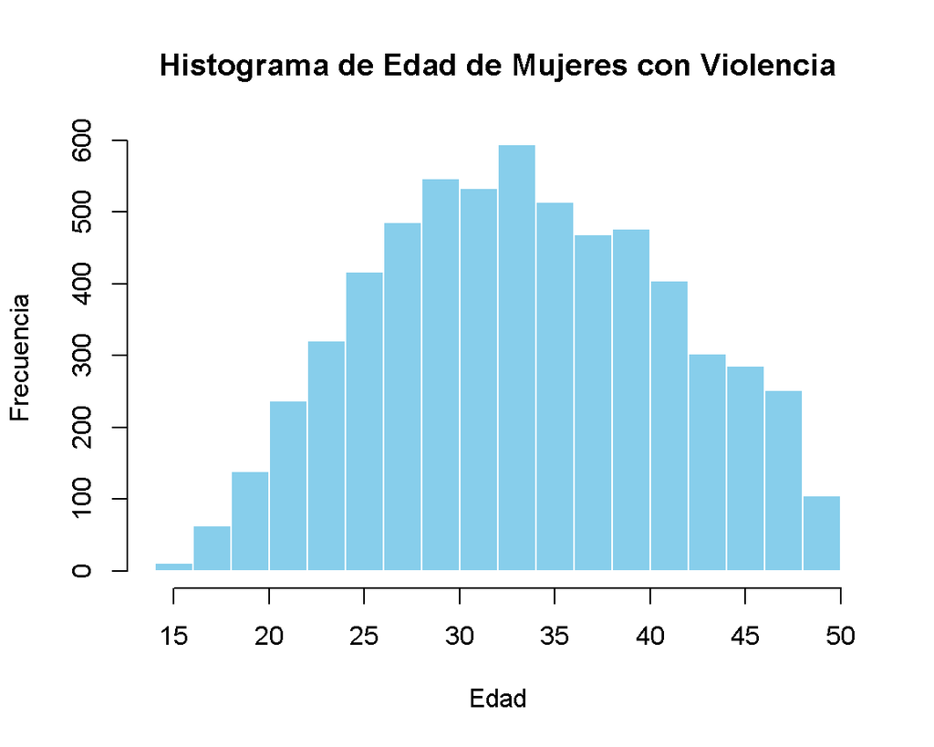

### Distribución de casos que registran al menos un tipo de violencia contra la mujer a nivel nacional por departamentos

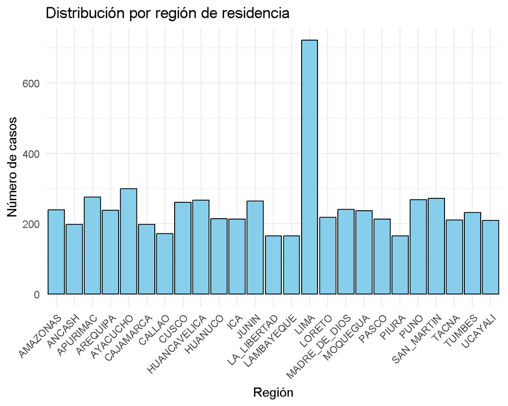

```
     AMAZONAS        ANCASH      APURIMAC      AREQUIPA      AYACUCHO
          239           198           275           238           299
    CAJAMARCA        CALLAO         CUSCO  HUANCAVELICA       HUANUCO
          198           172           260           267           214
          ICA         JUNIN   LA_LIBERTAD    LAMBAYEQUE          LIMA
          213           264           165           165           721
       LORETO MADRE_DE_DIOS      MOQUEGUA         PASCO         PIURA
          218           240           237           213           165
         PUNO    SAN_MARTIN         TACNA        TUMBES       UCAYALI
          268           272           211           232           209
```

# Modelo

### Modelo de regresión logística binaria

Regresión Logística

|  | Sufrir violencia (I) |
| --- | --- |
| (Intercept) | -1.451*** |
|  | (0.160) |
| V012 | 0.031*** |
|  | (0.002) |
| V025rural | -0.289*** |
|  | (0.045) |
| lenguaespañol | -0.205*** |
|  | (0.038) |
| V149prim_inc | 0.143 |
|  | (0.147) |
| V149prim_com | 0.004 |
|  | (0.158) |
| V149sec_inc | 0.155 |
|  | (0.159) |
| V149sec_com | -0.046 |
|  | (0.158) |
| V149sup | -0.169 |
|  | (0.160) |
| V190pobre | -0.004 |
|  | (0.048) |
| V190medio | -0.111+ |
|  | (0.058) |
| V190rico | -0.313*** |
|  | (0.067) |
| V190rico_ext | -0.541*** |
|  | (0.079) |
| V155leer_palabras | -0.022 |
|  | (0.130) |
| V155leer_frases | 0.066 |
|  | (0.106) |
| V155no_tarjeta | -10.562 |
|  | (97.371) |
| V155ciega | -0.414 |
|  | (0.849) |
| V136 | -0.031** |
|  | (0.010) |
| Num.Obs. | 21321 |
| AIC | 25183.2 |
| BIC | 25326.6 |
| Log.Lik. | -12573.590 |
| F | 27.170 |
| RMSE | 0.45 |

+ p < 0.1, * p < 0.05, ** p < 0.01, *** p < 0.001

### Consideraciones

A partir de los sectores socioeconómicos se determina que el hecho de ser una mujer con alto poder adquisitivo disminuye en promedio en un factor de -0.42 al odds ratio de sufrir algún tipo de violencia dentro del ámbito familiar a diferencia de otros sectores con otro nivel de poder adquisitivo.

Que una mujer tenga como primera lengua español disminuye en promedio en un factor de -0.19 al odds ratio de sufrir algún tipo de violencia dentro del ámbito familiar.

### Modelo de regresión logística binaria con coeficientes exponenciados

Comparando Regresión Logísticas (Coeficientes Exponenciados)

|  | Sufrir violencia (I) |
| --- | --- |
| (Intercept) | 0.23440652*** |
|  | [0.17094, 0.3203] |
| V012 | 1.03115774*** |
|  | [1.02688, 1.0355] |
| V025rural | 0.74911834*** |
|  | [0.68551, 0.8184] |
| lenguaespañol | 0.81440844*** |
|  | [0.75649, 0.8769] |
| V149prim_inc | 1.15322192 |
|  | [0.86575, 1.5412] |
| V149prim_com | 1.00446339 |
|  | [0.73783, 1.3714] |
| V149sec_inc | 1.16768254 |
|  | [0.85568, 1.5983] |
| V149sec_com | 0.95538461 |
|  | [0.70198, 1.3043] |
| V149sup | 0.84428190 |
|  | [0.61827, 1.1564] |
| V190pobre | 0.99622134 |
|  | [0.90665, 1.0946] |
| V190medio | 0.89483429+ |
|  | [0.79877, 1.0024] |
| V190rico | 0.73103408*** |
|  | [0.64124, 0.8331] |
| V190rico_ext | 0.58195512*** |
|  | [0.49812, 0.6792] |
| V155leer_palabras | 0.97788346 |
|  | [0.75801, 1.2612] |
| V155leer_frases | 1.06783278 |
|  | [0.86897, 1.3150] |
| V155no_tarjeta | 0.00002588 |
|  | [ NA, 1.8267] |
| V155ciega | 0.66122194 |
|  | [0.09312, 3.1553] |
| V136 | 0.96915764** |
|  | [0.95065, 0.9879] |
| Num.Obs. | 21321 |
| AIC | 25183.2 |
| BIC | 25326.6 |
| RMSE | 0.45 |
| Log.Lik. | -12573.590 |

+ p < 0.1, * p < 0.05, ** p < 0.01, *** p < 0.001

### Consideraciones

De acuerdo a los coeficientes exponenciados se puede deducir que el odds ratio de sufrir algún tipo de violencia se eleva en promedio 3% cada vez que la edad de la mujer aumenta en uno.

```
    V012
1.031158
```

```
     V136
0.9691576
```

# Resultados y Hallazgos

### Efectos Marginales promedio

Efectos Marginales Promedio- Modelo I

| factor | AME | SE | z | p | lower | upper |
| --- | --- | --- | --- | --- | --- | --- |
| lenguaespañol | -0.0421482 | 0.0078931 | -5.3398823 | 0.0000001 | -0.0576184 | -0.0266780 |
| V012 | 0.0061582 | 0.0004197 | 14.6713673 | 0.0000000 | 0.0053356 | 0.0069809 |
| V025rural | -0.0567154 | 0.0086492 | -6.5573412 | 0.0000000 | -0.0736675 | -0.0397634 |
| V136 | -0.0062879 | 0.0019658 | -3.1985948 | 0.0013810 | -0.0101408 | -0.0024349 |
| V149prim_com | 0.0009083 | 0.0322094 | 0.0281997 | 0.9775029 | -0.0622210 | 0.0640376 |
| V149prim_inc | 0.0298506 | 0.0300207 | 0.9943338 | 0.3200604 | -0.0289889 | 0.0886900 |
| V149sec_com | -0.0092150 | 0.0321582 | -0.2865508 | 0.7744563 | -0.0722440 | 0.0538140 |
| V149sec_inc | 0.0325331 | 0.0325916 | 0.9982063 | 0.3181793 | -0.0313452 | 0.0964115 |
| V149sup | -0.0332917 | 0.0323954 | -1.0276667 | 0.3041066 | -0.0967855 | 0.0302021 |
| V155ciega | -0.0734463 | 0.1354418 | -0.5422719 | 0.5876312 | -0.3389073 | 0.1920148 |
| V155leer_frases | 0.0130197 | 0.0206899 | 0.6292798 | 0.5291659 | -0.0275317 | 0.0535711 |
| V155leer_palabras | -0.0043549 | 0.0252856 | -0.1722268 | 0.8632592 | -0.0539138 | 0.0452041 |
| V155no_tarjeta | -0.2766869 | 0.0199543 | -13.8660323 | 0.0000000 | -0.3157966 | -0.2375772 |
| V190medio | -0.0228817 | 0.0119225 | -1.9192028 | 0.0549587 | -0.0462494 | 0.0004860 |
| V190pobre | -0.0007956 | 0.0100985 | -0.0787846 | 0.9372039 | -0.0205883 | 0.0189971 |
| V190rico | -0.0618688 | 0.0130068 | -4.7566391 | 0.0000020 | -0.0873617 | -0.0363759 |
| V190rico_ext | -0.1014715 | 0.0140937 | -7.1997804 | 0.0000000 | -0.1290946 | -0.0738484 |

### Efectos marginales promedios

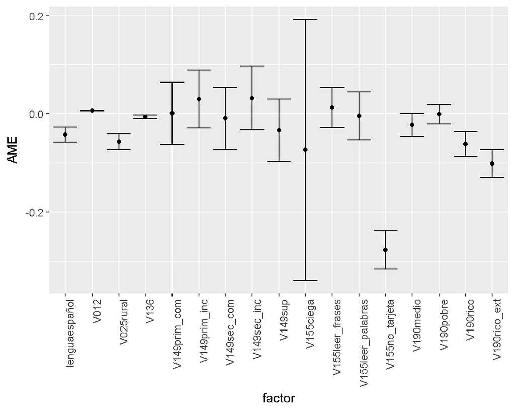

### Interpretación de los resultados

Lengua (español): El AME de esta variable es -0.0421482, lo que indica que, en promedio, las mujeres cuya lengua materna no es el español tienen una mayor probabilidad de experimentar violencia en comparación con aquellas cuya lengua materna es el español. Este efecto es altamente significativo porque tiene un p valor igual a 0.0000001

Edad: El AME es 0.0061582, esto significa que, por cada año adicional de edad, la probabilidad de que una mujer sea victima de violencia aumenta en 0.0061582 unidades. Este efecto también es altamente significativo con un p valor igual a 0.0000000

Ámbito rural: El AME es -0.0567154, indicando que vivir en áreas rurales está asociado, en promedio, con una menor probabilidad de que una mujer sea victima de violencia en comparación con vivir en áreas urbanas. Este efecto es altamente significativo con p = 0.0000000

Número de miembros en la familia: El AME es -0.0062879, lo que sugiere que por cada miembro adicional en el hogar, la probabilidad de que una mujer sea violentada disminuye en 0.0062879 unidades. Este efecto es significativo a un nivel de p = 0.0013810.

Las diferentes categorias del último nivel educativo alcanzado por la mujer no son estadísticamente significativas porque el p valor es mayor que 0.05 en todos los casos, lo que indica que estos niveles educativos no tienen un efecto significativo en la variable dependiente según este modelo.

Con respecto a la variable del nivel de riqueza del hogar al que pertenece la mujer, los efectos marginales sugieren que los niveles más altos de riqueza, es decir rico y rico extremo, están asociados con una menor probabilidad de experimentar violencia.

# Analisis factorial y conglomerado

### Análisis de Correspondencias Múltiples: individuos

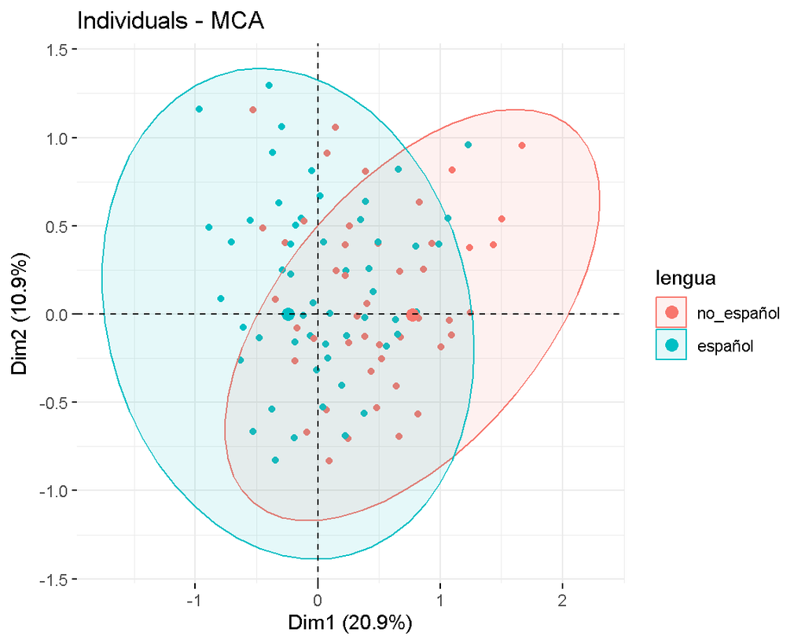

### Análisis de Correspondencias Múltiples: Variables con contribuciones

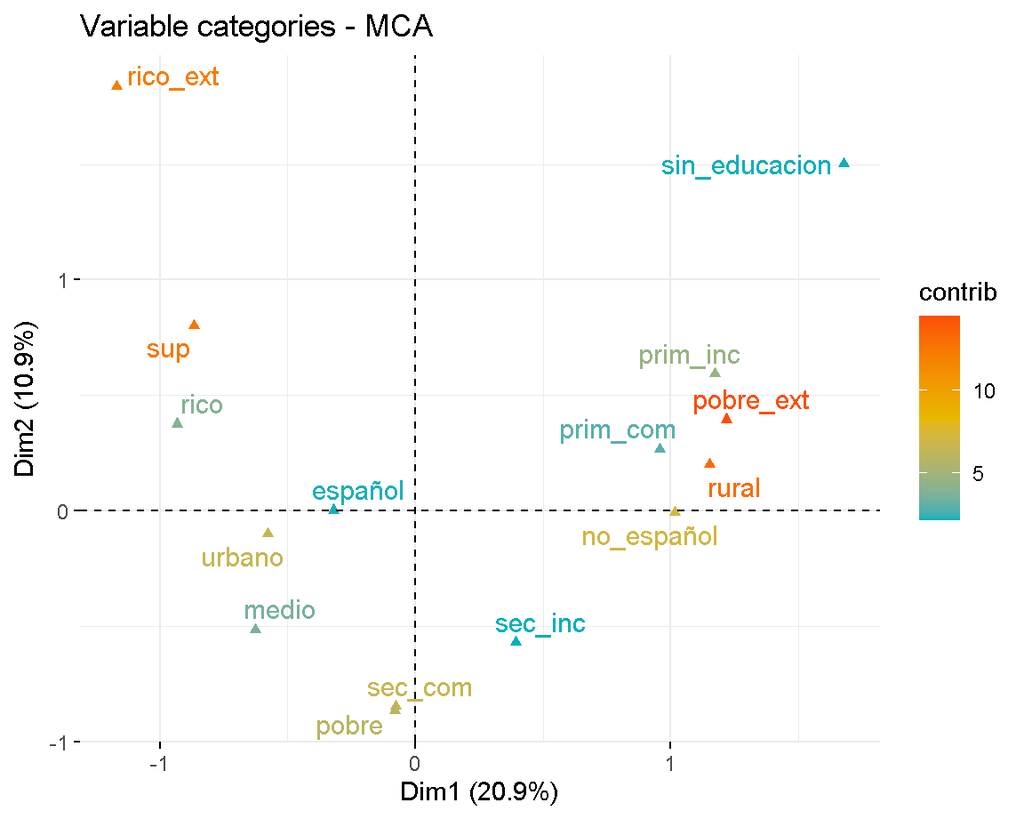

### Analisis conglomerado

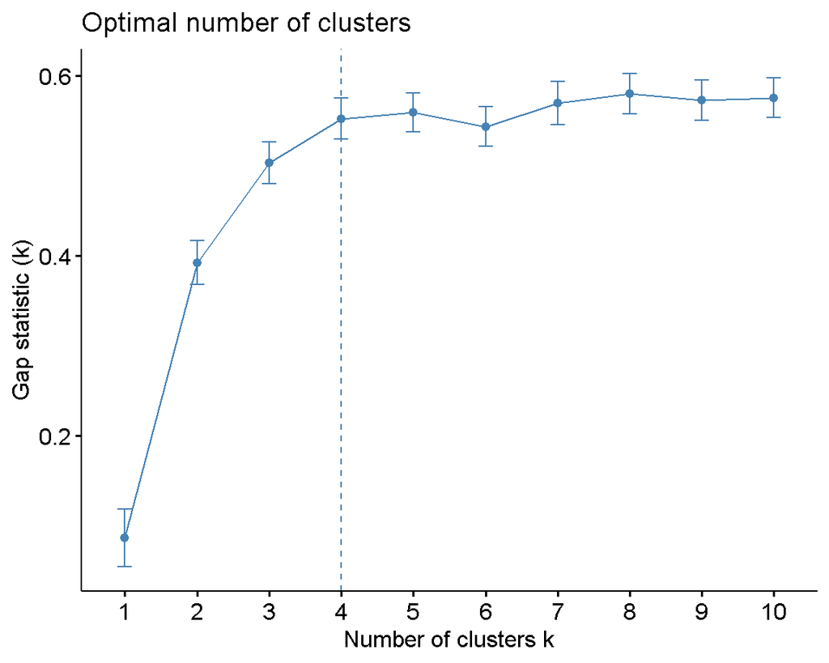

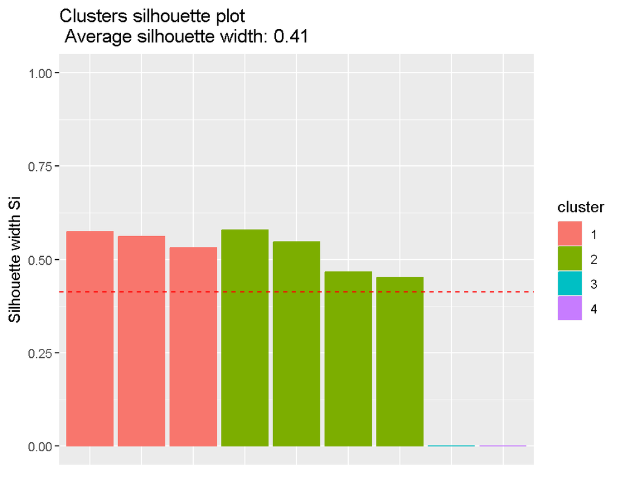